# War on Terror project 2 Ali Mutasim

2026-04-16

```r
library(dplyr)
```

```r
library(ggplot2)
library(MASS)      # for stepAIC
library(rpart)     # decision tree
library(rpart.plot)
```

libraries were imported to do data manipulation, visualization, regression modeling, feature selection, and decsision trees.

```r
Terror <- read.csv("TerrorData.csv")

Terror$iyear <- as.numeric(Terror$iyear)
Terror$nkill <- as.numeric(Terror$nkill)
Terror$nwound <- as.numeric(Terror$nwound)
Terror$propvalue <- as.numeric(Terror$propvalue)

Terror$nkill[is.na(Terror$nkill)] <- 0
Terror$nwound[is.na(Terror$nwound)] <- 0
Terror$propvalue[is.na(Terror$propvalue)] <- 0
```

the variables are converted into numeric form so that R can analzye and calculate well. it replaces NA values with zeros so that errors aren’t caused.

```r
Terror$casualties <- Terror$nkill + Terror$nwound
Terror$log_casualties <- log1p(Terror$casualties)
Terror$log_prop <- log1p(Terror$propvalue)
Terror$period <- ifelse(Terror$iyear < 2001, "Pre-2001", "Post-2001")
Terror$period <- as.factor(Terror$period)
```

here number of killed and wounded into one variable called casualties. variable to show severity. log transforamtion is used to make them suitable for regression modeling. a variable period is created so that attacks are compared pre and post 2001.

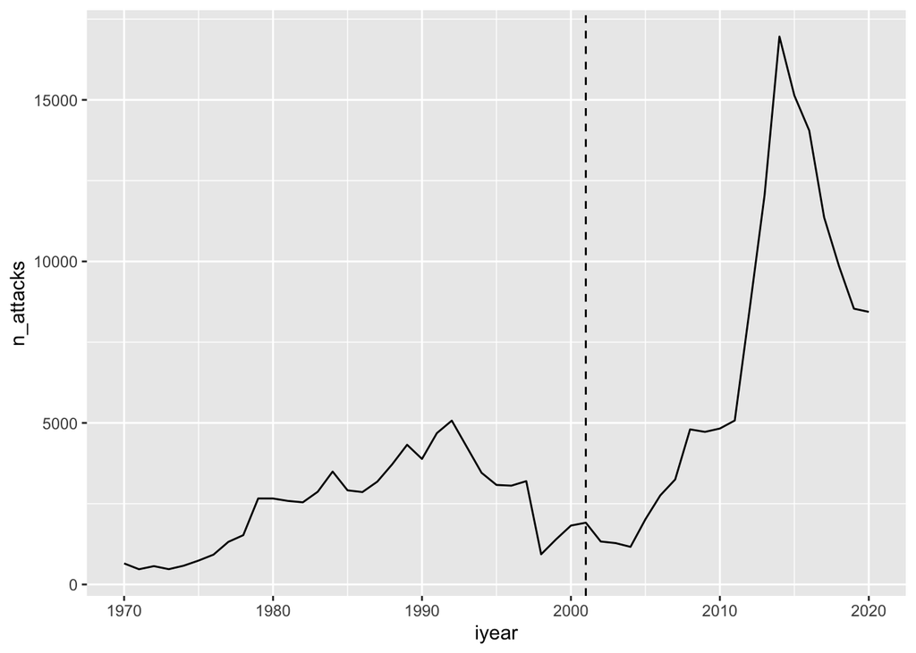

```r
attacks_per_year <- Terror %>%
  group_by(iyear) %>%
  summarise(n_attacks = n(), .groups = "drop") %>%
  mutate(period = ifelse(iyear < 2001, "Pre-2001", "Post-2001"))

ggplot(attacks_per_year, aes(x = iyear, y = n_attacks)) +
  geom_line() +
  geom_vline(xintercept = 2001, linetype="dashed")
```

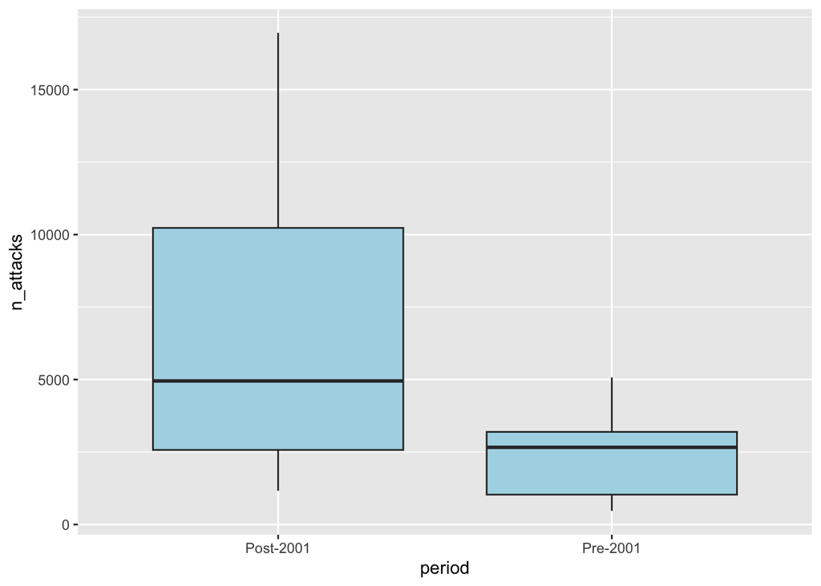

```r
ggplot(attacks_per_year, aes(x = period, y = n_attacks)) +
  geom_boxplot(fill="lightblue")
```

```r
t.test(n_attacks ~ period, data = attacks_per_year)
```

```
##
##  Welch Two Sample t-test
##
## data:  n_attacks by period
## t = 3.9445, df = 20.862, p-value = 0.0007494
## alternative hypothesis: true difference in means between group Post-2001 and group Pre-2001 is not equal to 0
## 95 percent confidence interval:
##  2133.130 6894.637
## sample estimates:
## mean in group Post-2001  mean in group Pre-2001
##                6902.450                2388.567
```

Plots are created here by grouping attacks in each year and seeing how the frequency of these attaks change over time. a line plot is created to show how the number of attacks changes over time. a boxplot is created to show the frequency of attacks pre and post 2001 or 9/11

# 5. TWO-VARIABLE GRAPHICS (REQUIRED)

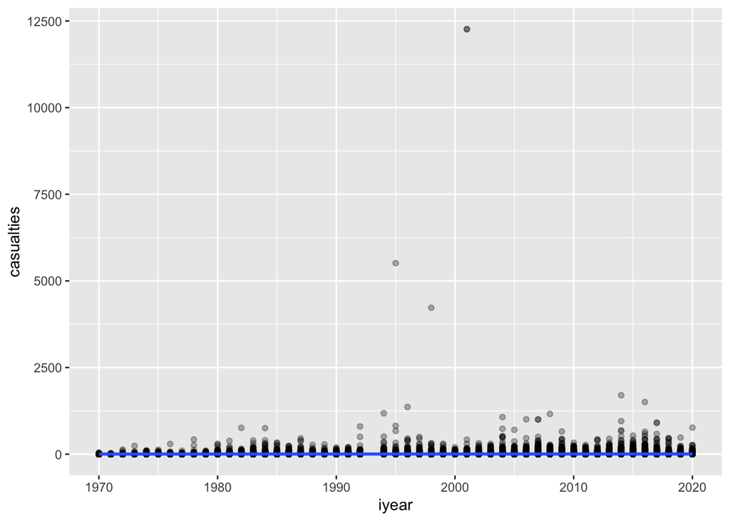

```r
# Scatterplot: casualties vs year
ggplot(Terror, aes(x = iyear, y = casualties)) +
  geom_point(alpha = 0.3) +
  geom_smooth(method = "lm")
```

```r
# Correlation matrix (numeric only)
numeric_vars <- Terror[, c("iyear","nkill","nwound","propvalue","casualties")]
cor(numeric_vars, use="complete.obs")
```

```
##                   iyear       nkill      nwound    propvalue casualties
## iyear       1.000000000 0.020694303 0.009821054 -0.005063945 0.01361170
## nkill       0.020694303 1.000000000 0.434912762  0.007220625 0.62330578
## nwound      0.009821054 0.434912762 1.000000000  0.016394548 0.97523358
## propvalue  -0.005063945 0.007220625 0.016394548  1.000000000 0.01601072
## casualties  0.013611701 0.623305779 0.975233575  0.016010724 1.00000000
```

This step involves two-variable graphics to examine the relationships in the data. To determine whether the intensity of attacks varies with time a scatterplot of year vs casualties is plotted. The numeric variables are also correlated to one another, so that you can learn whether or not the variables move together, and whether there are any strong linear associations among them.

# 6. GLM (REGRESSION)

```r
model_full <- lm(log_casualties ~ iyear + attacktype1_txt + region_txt + period,
                 data = Terror)

summary(model_full)
```

```
##
## Call:
## lm(formula = log_casualties ~ iyear + attacktype1_txt + region_txt +
##     period, data = Terror)
##
## Residuals:
##     Min      1Q  Median      3Q     Max
## -1.4993 -0.6731 -0.1901  0.5098  9.3810
##
## Coefficients:
##                                                      Estimate Std. Error
## (Intercept)                                         7.3656077  0.8617758
## iyear                                              -0.0032135  0.0004271
## attacktype1_txtAssassination                       -0.2675977  0.0082226
## attacktype1_txtBombing/Explosion                   -0.2373391  0.0055949
## attacktype1_txtFacility/Infrastructure Attack      -0.9221301  0.0102417
## attacktype1_txtHijacking                           -0.7676470  0.0362885
## attacktype1_txtHostage Taking (Barricade Incident) -0.3473296  0.0295471
## attacktype1_txtHostage Taking (Kidnapping)         -0.7235807  0.0095140
## attacktype1_txtUnarmed Assault                     -0.1554520  0.0287470
## attacktype1_txtUnknown                              0.0384244  0.0105422
## region_txtCentral America & Caribbean               0.0300287  0.0560097
## region_txtCentral Asia                              0.3503359  0.0687680
## region_txtEast Asia                                 0.1356171  0.0647106
## region_txtEastern Europe                            0.0595684  0.0567746
## region_txtMiddle East & North Africa                0.5338415  0.0553267
## region_txtNorth America                            -0.1342765  0.0573590
## region_txtSouth America                            -0.0094204  0.0555391
## region_txtSouth Asia                                0.4483594  0.0553237
## region_txtSoutheast Asia                            0.1814240  0.0557426
## region_txtSub-Saharan Africa                        0.5255661  0.0555240
## region_txtWestern Europe                           -0.1714164  0.0555849
## periodPre-2001                                     -0.1223622  0.0117833
##                                                    t value Pr(>|t|)
## (Intercept)                                          8.547  < 2e-16 ***
## iyear                                               -7.525 5.30e-14 ***
## attacktype1_txtAssassination                       -32.544  < 2e-16 ***
## attacktype1_txtBombing/Explosion                   -42.421  < 2e-16 ***
## attacktype1_txtFacility/Infrastructure Attack      -90.037  < 2e-16 ***
## attacktype1_txtHijacking                           -21.154  < 2e-16 ***
## attacktype1_txtHostage Taking (Barricade Incident) -11.755  < 2e-16 ***
## attacktype1_txtHostage Taking (Kidnapping)         -76.054  < 2e-16 ***
## attacktype1_txtUnarmed Assault                      -5.408 6.40e-08 ***
## attacktype1_txtUnknown                               3.645 0.000268 ***
## region_txtCentral America & Caribbean                0.536 0.591867
## region_txtCentral Asia                               5.094 3.50e-07 ***
## region_txtEast Asia                                  2.096 0.036106 *
## region_txtEastern Europe                             1.049 0.294083
## region_txtMiddle East & North Africa                 9.649  < 2e-16 ***
## region_txtNorth America                             -2.341 0.019234 *
## region_txtSouth America                             -0.170 0.865311
## region_txtSouth Asia                                 8.104 5.33e-16 ***
## region_txtSoutheast Asia                             3.255 0.001135 **
## region_txtSub-Saharan Africa                         9.466  < 2e-16 ***
## region_txtWestern Europe                            -3.084 0.002044 **
## periodPre-2001                                     -10.384  < 2e-16 ***
## ---
## Signif. codes:  0 '***' 0.001 '**' 0.01 '*' 0.05 '.' 0.1 ' ' 1
##
## Residual standard error: 0.9915 on 209684 degrees of freedom
## Multiple R-squared:  0.1256, Adjusted R-squared:  0.1256
## F-statistic:  1435 on 21 and 209684 DF,  p-value: < 2.2e-16
```

A regression model is then constructed to describe the severity of attacks using the script. In this model, the dependent variable will be the log-transformed number of casualties, with the predictors being year, type of attack, region and period. This enables you to test the relationship between that and the other factors in the model and the other factors that are associated with more severe attacks.

# 7. FEATURE SELECTION (IMPORTANT)

```r
model_step <- stepAIC(model_full, direction = "both")
```

```
## Start:  AIC=-3577.32
## log_casualties ~ iyear + attacktype1_txt + region_txt + period
##
##                   Df Sum of Sq    RSS     AIC
## <none>                         206116 -3577.3
## - iyear            1      55.7 206171 -3522.7
## - period           1     106.0 206222 -3471.5
## - region_txt      11    8528.3 214644  4902.8
## - attacktype1_txt  8   12598.5 218714  8848.2
```

```r
summary(model_step)
```

```
##
## Call:
## lm(formula = log_casualties ~ iyear + attacktype1_txt + region_txt +
##     period, data = Terror)
##
## Residuals:
##     Min      1Q  Median      3Q     Max
## -1.4993 -0.6731 -0.1901  0.5098  9.3810
##
## Coefficients:
##                                                      Estimate Std. Error
## (Intercept)                                         7.3656077  0.8617758
## iyear                                              -0.0032135  0.0004271
## attacktype1_txtAssassination                       -0.2675977  0.0082226
## attacktype1_txtBombing/Explosion                   -0.2373391  0.0055949
## attacktype1_txtFacility/Infrastructure Attack      -0.9221301  0.0102417
## attacktype1_txtHijacking                           -0.7676470  0.0362885
## attacktype1_txtHostage Taking (Barricade Incident) -0.3473296  0.0295471
## attacktype1_txtHostage Taking (Kidnapping)         -0.7235807  0.0095140
## attacktype1_txtUnarmed Assault                     -0.1554520  0.0287470
## attacktype1_txtUnknown                              0.0384244  0.0105422
## region_txtCentral America & Caribbean               0.0300287  0.0560097
## region_txtCentral Asia                              0.3503359  0.0687680
## region_txtEast Asia                                 0.1356171  0.0647106
## region_txtEastern Europe                            0.0595684  0.0567746
## region_txtMiddle East & North Africa                0.5338415  0.0553267
## region_txtNorth America                            -0.1342765  0.0573590
## region_txtSouth America                            -0.0094204  0.0555391
## region_txtSouth Asia                                0.4483594  0.0553237
## region_txtSoutheast Asia                            0.1814240  0.0557426
## region_txtSub-Saharan Africa                        0.5255661  0.0555240
## region_txtWestern Europe                           -0.1714164  0.0555849
## periodPre-2001                                     -0.1223622  0.0117833
##                                                    t value Pr(>|t|)
## (Intercept)                                          8.547  < 2e-16 ***
## iyear                                               -7.525 5.30e-14 ***
## attacktype1_txtAssassination                       -32.544  < 2e-16 ***
## attacktype1_txtBombing/Explosion                   -42.421  < 2e-16 ***
## attacktype1_txtFacility/Infrastructure Attack      -90.037  < 2e-16 ***
## attacktype1_txtHijacking                           -21.154  < 2e-16 ***
## attacktype1_txtHostage Taking (Barricade Incident) -11.755  < 2e-16 ***
## attacktype1_txtHostage Taking (Kidnapping)         -76.054  < 2e-16 ***
## attacktype1_txtUnarmed Assault                      -5.408 6.40e-08 ***
## attacktype1_txtUnknown                               3.645 0.000268 ***
## region_txtCentral America & Caribbean                0.536 0.591867
## region_txtCentral Asia                               5.094 3.50e-07 ***
## region_txtEast Asia                                  2.096 0.036106 *
## region_txtEastern Europe                             1.049 0.294083
## region_txtMiddle East & North Africa                 9.649  < 2e-16 ***
## region_txtNorth America                             -2.341 0.019234 *
## region_txtSouth America                             -0.170 0.865311
## region_txtSouth Asia                                 8.104 5.33e-16 ***
## region_txtSoutheast Asia                             3.255 0.001135 **
## region_txtSub-Saharan Africa                         9.466  < 2e-16 ***
## region_txtWestern Europe                            -3.084 0.002044 **
## periodPre-2001                                     -10.384  < 2e-16 ***
## ---
## Signif. codes:  0 '***' 0.001 '**' 0.01 '*' 0.05 '.' 0.1 ' ' 1
##
## Residual standard error: 0.9915 on 209684 degrees of freedom
## Multiple R-squared:  0.1256, Adjusted R-squared:  0.1256
## F-statistic:  1435 on 21 and 209684 DF,  p-value: < 2.2e-16
```

# 8. MODEL EVALUATION

```r
# R-squared
summary(model_step)$r.squared
```

```
## [1] 0.1256483
```

```r
# Adjusted R-squared
summary(model_step)$adj.r.squared
```

```
## [1] 0.1255608
```

```r
# ANOVA comparison
anova(model_step)
```

```
## Analysis of Variance Table
##
## Response: log_casualties
##                     Df Sum Sq Mean Sq F value    Pr(>F)
## iyear                1   5369  5369.0 5461.92 < 2.2e-16 ***
## attacktype1_txt      8  15515  1939.4 1972.94 < 2.2e-16 ***
## region_txt          11   8630   784.5  798.12 < 2.2e-16 ***
## period               1    106   106.0  107.83 < 2.2e-16 ***
## Residuals       209684 206116     1.0
## ---
## Signif. codes:  0 '***' 0.001 '**' 0.01 '*' 0.05 '.' 0.1 ' ' 1
```

After the last model has been selected, the script analyses the performance of the model. It analyzes the value of the R-squared and adjusted R-squared to understand the extent of the variation in the severity of the attack explained by the model. It also compares ANOVA output to determine the significance of the terms fitted in the model.

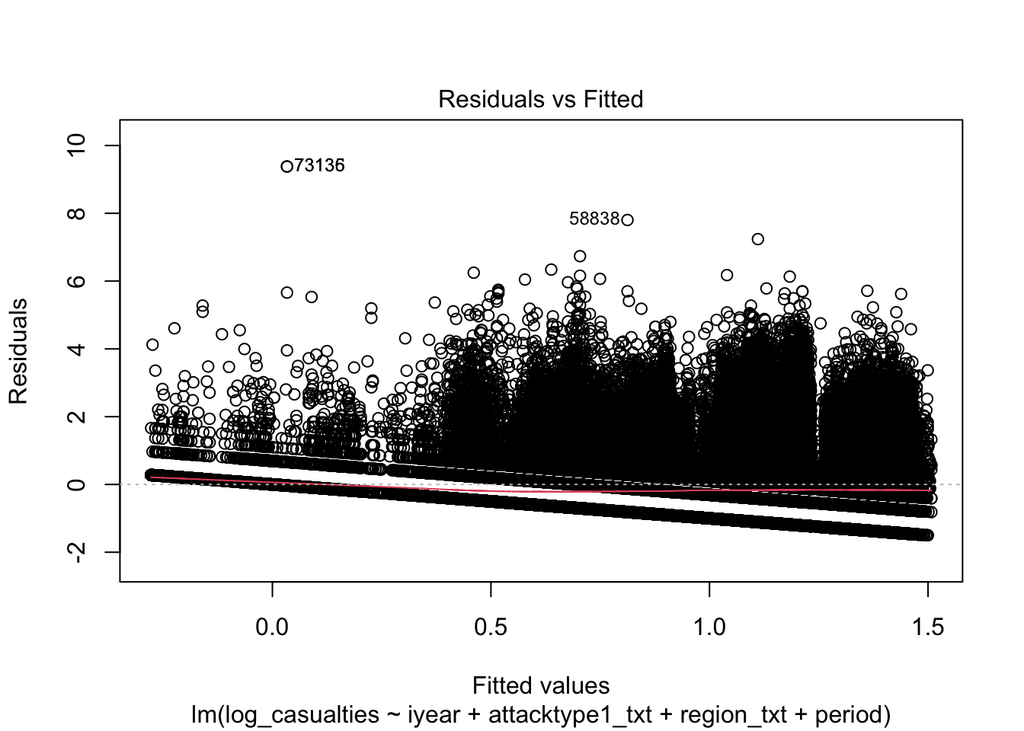

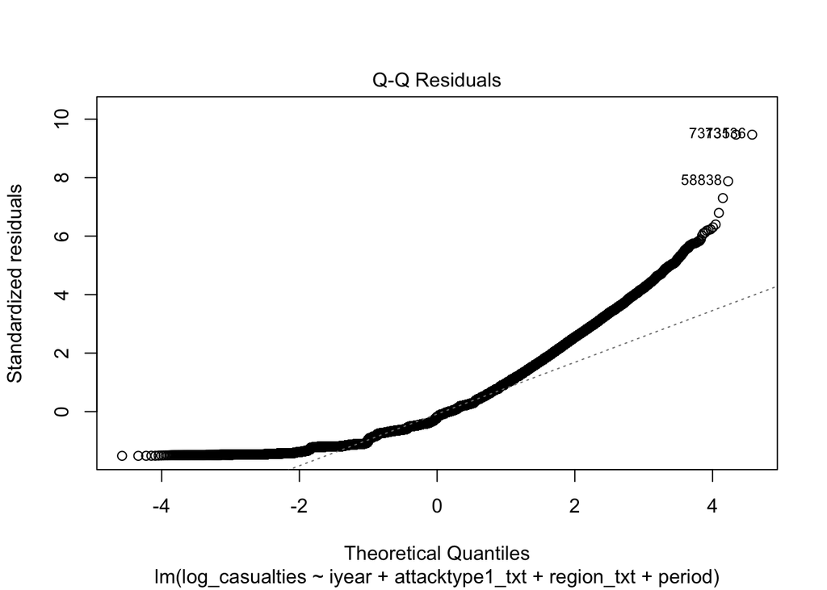

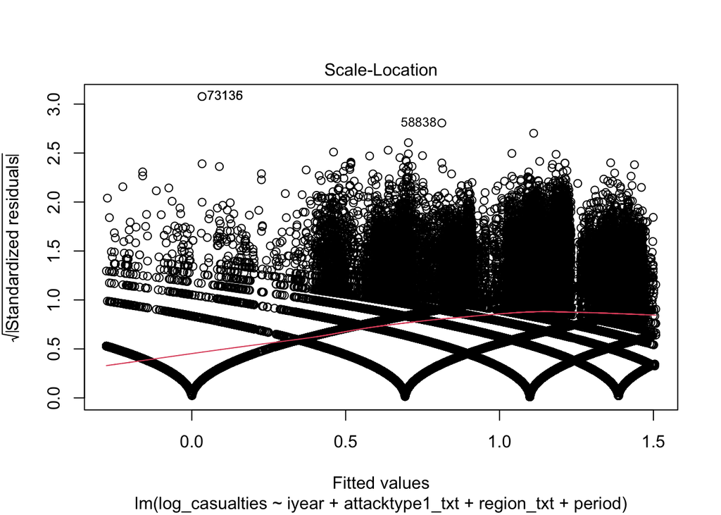

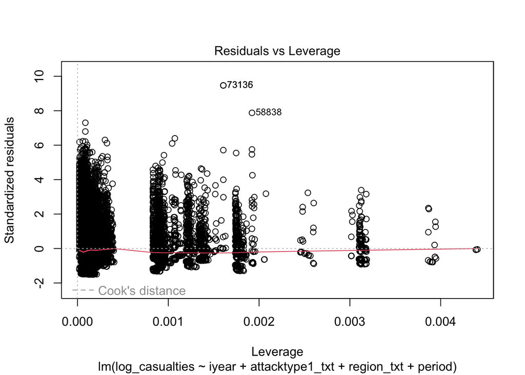

```r
#################################################
# 9. MODEL DIAGNOSTICS
#################################################

par(mfrow=c(1,1))
plot(model_step)
```

Improper assumptions of the regression model are then verified using the regression model on the basis of diagnostic plots. These plots assist you to observe whether or not the residual values are approximately normal, the variance is reasonably constant, and whether there are influential points that may substantially affect the outcomes. This is significant in the sense that when the assumptions of the regression are moderately satisfied, the conclusions of the regression are more trustworthy.

# 10. SECOND MODEL (PROPERTY DAMAGE)

```r
model_prop <- lm(log_prop ~ iyear + attacktype1_txt + region_txt + period,
                 data = Terror)

summary(model_prop)
```

```
##
## Call:
## lm(formula = log_prop ~ iyear + attacktype1_txt + region_txt +
##     period, data = Terror)
##
## Residuals:
##     Min      1Q  Median      3Q     Max
## -3.9799 -0.8690 -0.2277  0.1922 20.3729
##
## Coefficients:
##                                                     Estimate Std. Error t value
## (Intercept)                                        72.934655   2.035649  35.829
## iyear                                              -0.036292   0.001009 -35.966
## attacktype1_txtAssassination                       -0.590656   0.019704 -29.976
## attacktype1_txtBombing/Explosion                    0.451829   0.013688  33.008
## attacktype1_txtFacility/Infrastructure Attack       1.425437   0.029481  48.351
## attacktype1_txtHijacking                           -0.537941   0.098404  -5.467
## attacktype1_txtHostage Taking (Barricade Incident)  0.729276   0.076002   9.596
## attacktype1_txtHostage Taking (Kidnapping)         -0.157521   0.022648  -6.955
## attacktype1_txtUnarmed Assault                     -0.161487   0.069619  -2.320
## attacktype1_txtUnknown                             -0.012830   0.024679  -0.520
## region_txtCentral America & Caribbean               1.484858   0.142478  10.422
## region_txtCentral Asia                             -0.340521   0.169933  -2.004
## region_txtEast Asia                                -0.196530   0.161753  -1.215
## region_txtEastern Europe                           -0.262622   0.144819  -1.813
## region_txtMiddle East & North Africa               -0.103536   0.141370  -0.732
## region_txtNorth America                             1.025907   0.145964   7.029
## region_txtSouth America                             0.678545   0.141624   4.791
## region_txtSouth Asia                               -0.070885   0.141400  -0.501
## region_txtSoutheast Asia                            0.049538   0.142427   0.348
## region_txtSub-Saharan Africa                        0.158542   0.141972   1.117
## region_txtWestern Europe                            0.359246   0.141815   2.533
## periodPre-2001                                     -0.079967   0.027079  -2.953
##                                                    Pr(>|t|)
## (Intercept)                                         < 2e-16 ***
## iyear                                               < 2e-16 ***
## attacktype1_txtAssassination                        < 2e-16 ***
## attacktype1_txtBombing/Explosion                    < 2e-16 ***
## attacktype1_txtFacility/Infrastructure Attack       < 2e-16 ***
## attacktype1_txtHijacking                           4.59e-08 ***
```

[output cut: 8 more lines]

```
## region_txtMiddle East & North Africa                0.46394
## region_txtNorth America                            2.10e-12 ***
## region_txtSouth America                            1.66e-06 ***
## region_txtSouth Asia                                0.61615
## region_txtSoutheast Asia                            0.72798
## region_txtSub-Saharan Africa                        0.26412
## region_txtWestern Europe                            0.01130 *
## periodPre-2001                                      0.00315 **
## ---
## Signif. codes:  0 '***' 0.001 '**' 0.01 '*' 0.05 '.' 0.1 ' ' 1
##
## Residual standard error: 2.223 on 171767 degrees of freedom
##   (37917 observations deleted due to missingness)
## Multiple R-squared:  0.1453, Adjusted R-squared:  0.1452
## F-statistic:  1390 on 21 and 171767 DF,  p-value: < 2.2e-16
```

The script then makes a second regression model with log-transformed property damage as a dependent variable. The reason behind this is that the severity that your project is gauging on is not only based on casualties, but also on property damages, which is the second outcome. This model assists in determining what variables are related to more harmful attacks in terms of property damage.

# 11. DECISION TREE (OPTIONAL BUT STRONG)

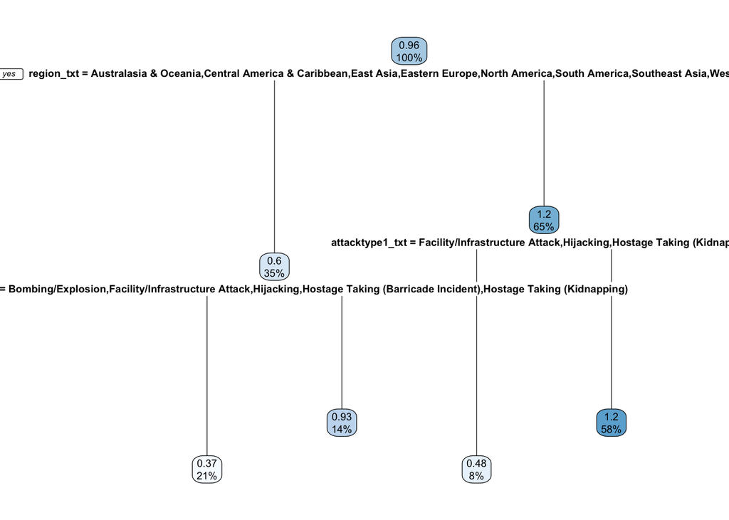

```r
tree_model <- rpart(log_casualties ~ iyear + attacktype1_txt + region_txt + period,
                    data = Terror,
                    method = "anova")

rpart.plot(tree_model)
```

A decision tree model of casualties is also provided in the script. A decision tree is more flexible in capturing nonlinear patterns and interactions than linear regression. This provides you another modeling method to contrast the regression results and makes your project stronger in the technical aspect.

# 12. CHI-SQUARE TESTS

```r
chisq.test(table(Terror$attacktype1_txt, Terror$period))
```

```
##
##  Pearson's Chi-squared test
##
## data:  table(Terror$attacktype1_txt, Terror$period)
## X-squared = 7445.5, df = 8, p-value < 2.2e-16
```

```r
chisq.test(table(Terror$region_txt, Terror$period))
```

```
##
##  Pearson's Chi-squared test
##
## data:  table(Terror$region_txt, Terror$period)
## X-squared = 80605, df = 11, p-value < 2.2e-16
```